# My Youtube Usage data story

We are going to look into the data I’ve collected for this report. To investigate my YouTube watching hobby. I have collected data for the amount of videos I have watched for each type, my enjoyment level, my watch time, and the time of the day.

## Video Watching Habits by Type

This first visualisation is an overview of my YouTube watching habits by showing the number of videos I watched for each different video type.

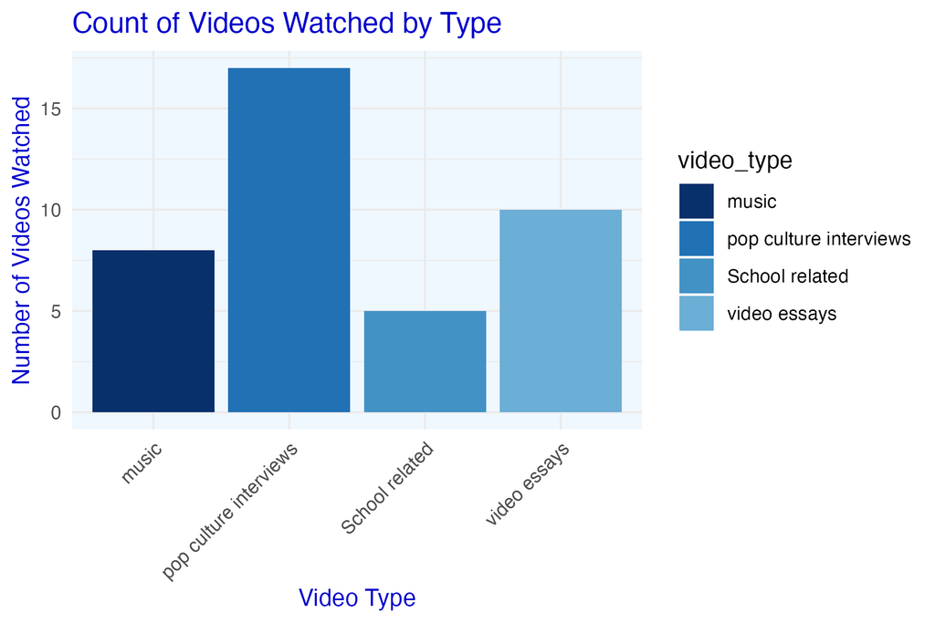

Bar chart showing the count of videos watched for each video type.

## Let’s look more deeply into the data

Here is a frequency line chart showing the distribution of video lengths, separated by video type, with mean lines added to make it more easy to understand. In this plot, the x-axis represents the video length in minutes, and the y-axis shows the frequency. This plot is seperated into thier own category so we can compare the distributions side-by-side.

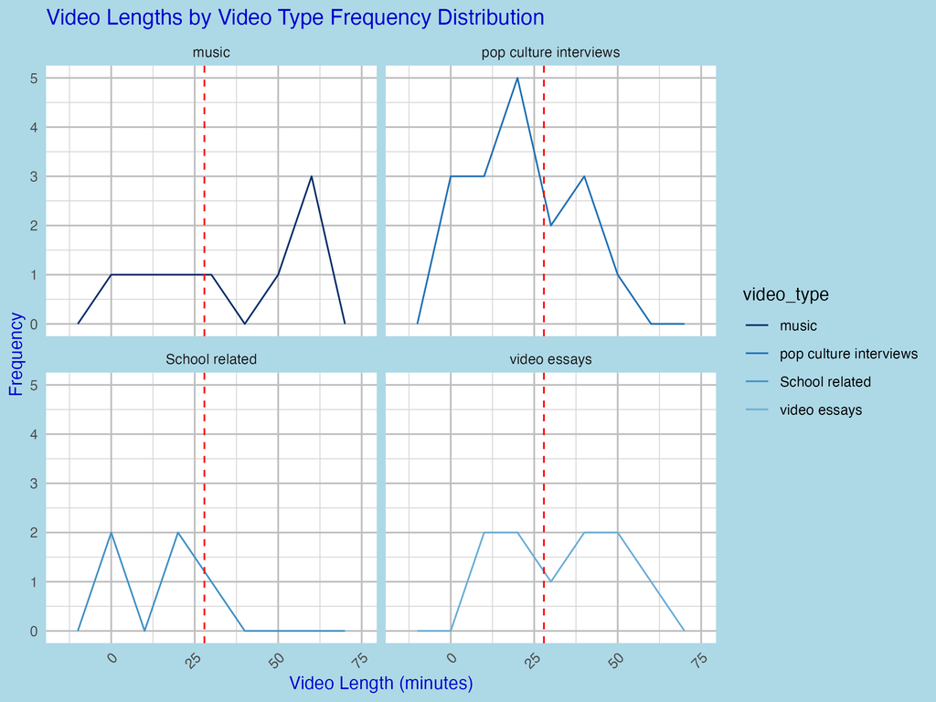

Frequency distribution of video lengths by video type.

The mean video length is around 25 minutes, and music videos are mostly over the mean line. I recall watching concerts while working out at the University gym, which explains the high frequency and minute time. But I also watch some short music videos. In the pop culture interview chat, some videos are below the mean timeline, as long interviews are not as popular nowadays. Still, there are exceptions, like the Apple Music interviews, which are normally over 45 minutes. The data in the school-related chat is not significant enough to require much explanation. I use discussions for help more instead of YouTube. Lastly, the data for the video essay chart is very steady. There are short and long video essays, and the data shows that I don’t have a preference. Comparing all four charts, we can see the data is very different for all 4 of them, which tells us very different information. This is also why I did four charts instead of grouping the data into one chart.

## What time do I watch my videos?

To explore the relationship between the type of video I watch and the time of day, I created this count plot. This plot uses points to represent each combination of video type and time range found in my data. The size of each point indicates how frequently that specific combination occurred, larger points mean I watched that type of video more often during that time range.

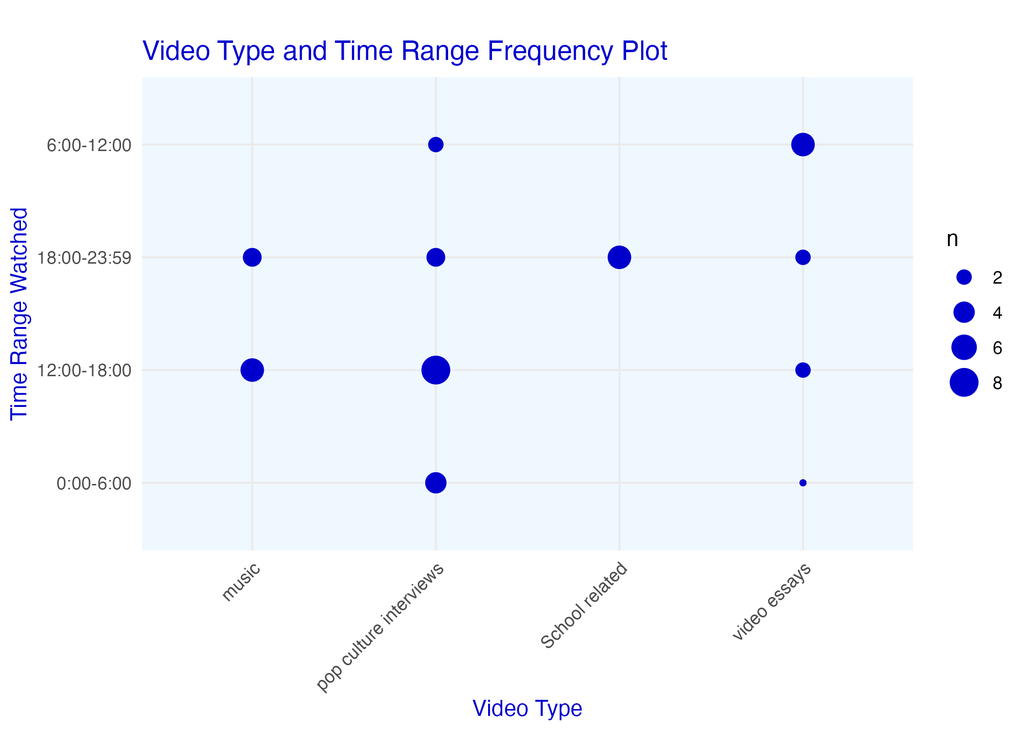

Count plot showing the frequency of video type and time range combinations.

## Conclution

To conclude, I have wasted many hours into watching YouTube, and most of them are not educational. But the non educational YouTube videos are my dopamine pills throughout the day and it take away my stress for a short perido of time.